# Project 2

##Continuous Linear Regression

```r
infert_ce<-infert%>%mutate(induced_c=induced-mean(induced,rm.na=T),spontaneous_c=spontaneous-mean(spontaneous,rm.na=T), parity_c=parity-mean(parity,rm.na=T),age_c=age-mean(age,rm.na=T))

fit<-lm(parity_c~spontaneous_c*age_c, data=infert_ce)
summary(fit)
```

```
##
## Call:
## lm(formula = parity_c ~ spontaneous_c * age_c, data = infert_ce)
##
## Residuals:
##     Min      1Q  Median      3Q     Max
## -1.8839 -0.8191 -0.3114  0.2493  4.2493
##
## Coefficients:
##                     Estimate Std. Error t value Pr(>|t|)
## (Intercept)          0.01177    0.07528   0.156   0.8759
## spontaneous_c        0.54109    0.10304   5.251 3.29e-07 ***
## age_c                0.02861    0.01442   1.984   0.0484 *
## spontaneous_c:age_c  0.03644    0.02082   1.750   0.0814 .
## ---
## Signif. codes:  0 '***' 0.001 '**' 0.01 '*' 0.05 '.' 0.1 ' ' 1
##
## Residual standard error: 1.181 on 244 degrees of freedom
## Multiple R-squared:  0.1206, Adjusted R-squared:  0.1098
## F-statistic: 11.16 on 3 and 244 DF,  p-value: 6.919e-07
```

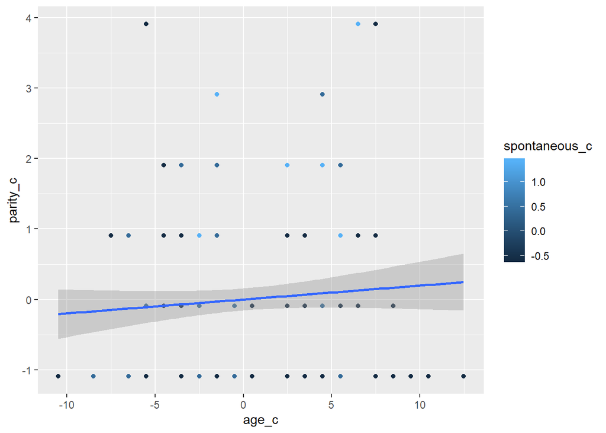

```r
ggplot(infert_ce, aes(age_c,parity_c))+geom_point(aes(color=spontaneous_c))+geom_smooth(method="lm")
```

```r
#Testing for linearity, normality, homoskedsaticity
library(lmtest)
```

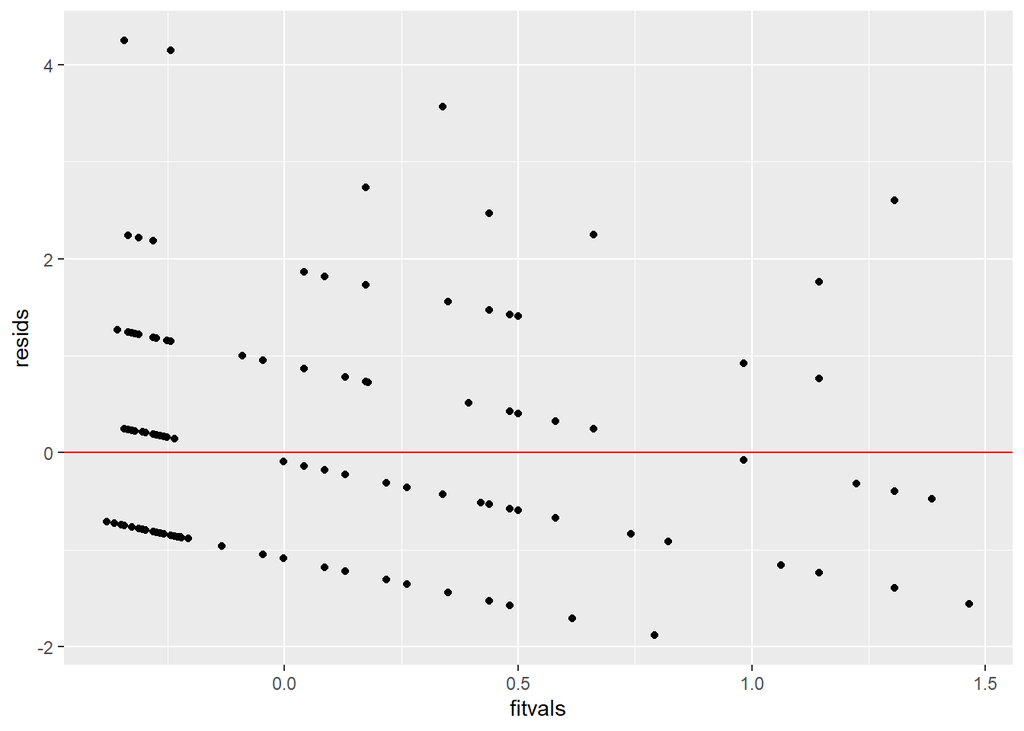

```r
resids<-fit$residuals
fitvals<-fit$fitted.values
ggplot()+geom_point(aes(fitvals,resids))+geom_hline(yintercept=0, color='red')
```

```r
bptest(fit)
```

```
##
##  studentized Breusch-Pagan test
##
## data:  fit
## BP = 3.3784, df = 3, p-value = 0.3369
```

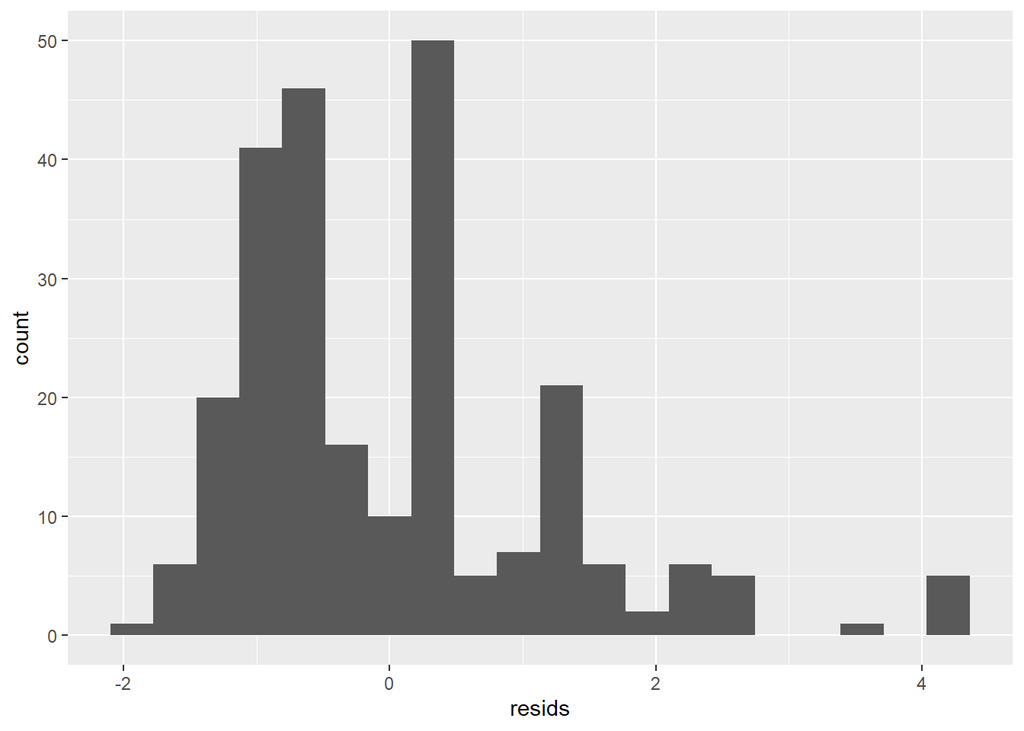

```r
ggplot()+geom_histogram(aes(resids), bins=20)
```

```r
shapiro.test(resids)
```

```
##
##  Shapiro-Wilk normality test
##
## data:  resids
## W = 0.88128, p-value = 5.306e-13
```

```r
#Recompute regression
??vcovHC
library(sandwich)
coeftest(fit,vcov=vcovHC(fit))
```

```
##
## t test of coefficients:
##
##                     Estimate Std. Error t value  Pr(>|t|)
## (Intercept)         0.011765   0.076635  0.1535   0.87811
## spontaneous_c       0.541088   0.109452  4.9436 1.427e-06 ***
## age_c               0.028614   0.016015  1.7867   0.07523 .
## spontaneous_c:age_c 0.036437   0.024466  1.4893   0.13771
## ---
## Signif. codes:  0 '***' 0.001 '**' 0.01 '*' 0.05 '.' 0.1 ' ' 1
```

```r
(sum((infert$parity-mean(infert$parity))^2)-sum(fit$residuals^2))/sum((infert$parity-mean(infert$parity))^2)
```

```
## [1] 0.1206122
```

```r
fit2<-lm(parity_c~spontaneous_c+age_c, data=infert_ce)
summary(fit2)
```

```
##
## Call:
## lm(formula = parity_c ~ spontaneous_c + age_c, data = infert_ce)
##
## Residuals:
##     Min      1Q  Median      3Q     Max
## -1.6527 -0.8674 -0.2336  0.3486  4.3683
##
## Coefficients:
##                Estimate Std. Error t value Pr(>|t|)
## (Intercept)   3.343e-15  7.530e-02   0.000   1.0000
## spontaneous_c 5.495e-01  1.034e-01   5.316 2.38e-07 ***
## age_c         2.619e-02  1.442e-02   1.817   0.0705 .
## ---
## Signif. codes:  0 '***' 0.001 '**' 0.01 '*' 0.05 '.' 0.1 ' ' 1
##
## Residual standard error: 1.186 on 245 degrees of freedom
## Multiple R-squared:  0.1096, Adjusted R-squared:  0.1023
## F-statistic: 15.08 on 2 and 245 DF,  p-value: 6.692e-07
```

```r
anova(fit,fit2,test="LRT")
```

```
## Analysis of Variance Table
##
## Model 1: parity_c ~ spontaneous_c * age_c
## Model 2: parity_c ~ spontaneous_c + age_c
##   Res.Df    RSS Df Sum of Sq Pr(>Chi)
## 1    244 340.21
## 2    245 344.48 -1   -4.2691  0.08015 .
## ---
## Signif. codes:  0 '***' 0.001 '**' 0.01 '*' 0.05 '.' 0.1 ' ' 1
```

The coefficient for spontaneous abortions is the difference between the predicted values of parity when age=0. So, as parity increases, the number of spontaneous abortions increases slightly by 0.54109 when holding all other variables constant. Similarly, as parity increases, age increases slightly by 0.02861. The interaction of age and spontaneous abortions increases slightly with parity as well by 0.03644.